# Análisis de Sentimientos CLA

Jorge Pastén

Agosto 25, 2024

# Análisis de Sentimientos y Temáticas de Tweets Relacionados a Caja los Andes

Link repositorio: https://github.com/Cokeloon/CLA-Jorge

## Introducción

En este análisis, se abordará el estudio de los tweets relacionados con Caja los Andes. El enfoque principal será doble: por un lado, se realizará un análisis de sentimientos para identificar las emociones predominantes expresadas en los tweets; por otro lado, se utilizará Latent Dirichlet Allocation (LDA) para identificar las temáticas principales. Los pasos a seguir durante el desarrollo de este análisis son los siguientes:

1. **Pre-procesamiento de datos**: Limpiar y preparar los datos textuales para el análisis.
2. **Visualizaciones base**: Crear visualizaciones iniciales para entender mejor la distribución de los datos.
3. **LDA para conocimiento de temáticas principales**: Identificar las temáticas clave en los tweets mediante LDA.
4. **Análisis de sentimientos**: Evaluar los sentimientos expresados en los tweets.
5. **Combinación de LDA y sentimientos por tema**: Integrar los resultados de LDA y el análisis de sentimientos para obtener una visión más completa.

A continuación, se presenta el código R utilizado para este análisis, junto con las salidas correspondientes.

## Análisis de Sentimientos - Jorge Pastén Abarca

Opcional(En caso de marcar error: “there is no package called”)

install.packages(“tidytext”, “wordcloud”, “quanteda”, “quanteda.textmodels”, “quanteda.textstats”, “quanteda.textplots”, “quanteda.dictionaries”, “quanteda.corpora”, “RColorBrewer”)

#### Cargar los paquetes necesarios

```r
# (1) Manipulación de datos
library(tidytext)
library(dplyr)
library(readxl)
library(ggplot2)
library(tidyverse)
library(wordcloud)
library(ggthemes)
library(topicmodels)
library(tm)
library(LDAvis)
library(servr)
library(ldatuning)
library(syuzhet)
library(textdata)


# (2) Quanteda : Cleaning and Loading Data    ----------------------------------

library(quanteda)
library(quanteda.textmodels)
library(quanteda.textstats)
library(quanteda.textplots)

# (3) Carga de Datos para trabajar

datos <- read.csv("dataset_Caso_2.csv")
```

## Pre-Procesamiento de Datos

```r
for(i in 1:nrow(datos)){
  if(str_detect(datos$texto_tweet[i],"@") == TRUE){
    datos$texto_tweet[i] <- str_remove_all(datos$texto_tweet[i], "@\\w+")
  }

  # Revisaremos más adelante si los # nos dicen algo importante
  # if(str_detect(datos$texto_tweet[i],"#") == TRUE){
  #   datos$texto_tweet[i] <- str_remove_all(datos$texto_tweet[i], "@\\w+")
  # }
}


data_corpus <- corpus(datos, text_field = "texto_tweet")


# Tokenización

toks <- tokens(data_corpus,
               remove_punct = T,
               remove_symbols = T,
               remove_url = T,
               remove_numbers = T) %>%
  tokens_remove(stopwords("es")) %>%
  tokens_remove(stopwords("en")) %>%
  tokens_tolower() %>%
  tokens_select(min_nchar = 3)
```

## Visualizaciones Previas

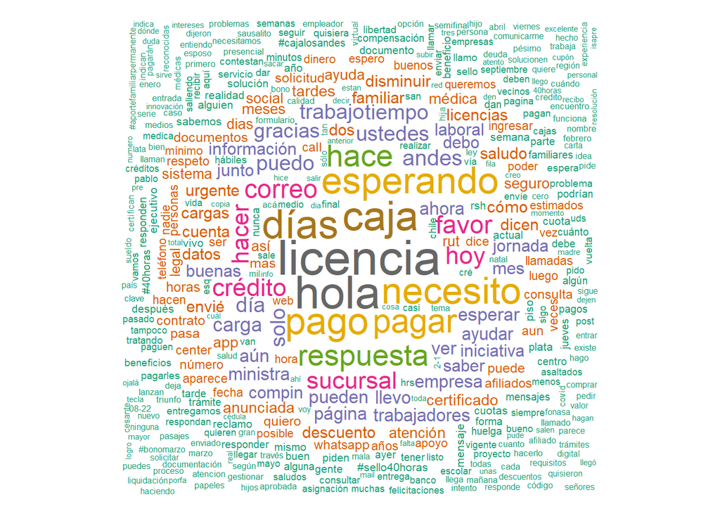

```r
## Wordcloud Base para Conocimiento de Datos

# DFM
dfm_toks <- dfm(toks)



# Wordcloud
textplot_wordcloud(dfm_toks, random_order = F,
                   colors = brewer.pal(8,"Dark2"))
```

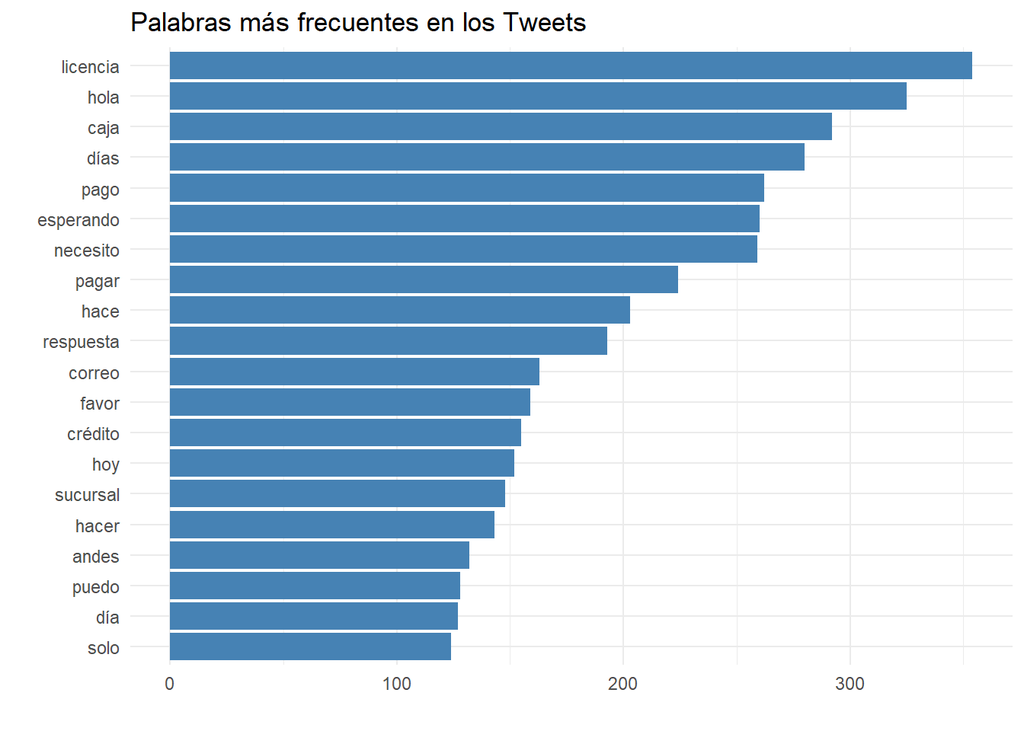

```r
# Visualización 2: Frecuencia de Palabras
top <- topfeatures(dfm_toks, 20)


# Convertir a DataFrame
top_words_df <- data.frame(
  word = names(top),
  freq = as.numeric(top)
)

# Gráfico de Barras
ggplot(top_words_df, aes(x = reorder(word,freq), y = freq)) +
  geom_bar(stat = "identity", fill = "steelblue") +
  coord_flip() +
  theme_minimal()+
  labs(title = "Palabras más frecuentes en los Tweets",
       x = "",
       y = "")
```

A partir de esto generamos un vector para eliminar palabras que son modismos chilenos, y palabras que no aportan al entendimiento del contenido.

```r
vector_sobra <- c("d","x","2-1","q","po","dm","cré","hola")


# Volvemos a filtrar los tokens

toks <- toks %>%
  tokens_remove(vector_sobra)

dfm_toks <- dfm(toks)
```

#### (5) Pasamos al modelado de LDA

Durante el proceso de limpieza de datos, se eliminaron palabras irrelevantes que no aportaban al entendimiento del contenido, así como las denominadas stopwords. Este paso es crucial para asegurar que el análisis se enfoque únicamente en la información relevante dentro de los tweets.

Sin embargo, este procedimiento ha revelado que algunos tweets quedaron completamente vacíos, es decir, sin palabras significativas después de la limpieza. Estos tweets, al no contener información útil para el análisis, deben ser identificados y eliminados para mantener la integridad y precisión del estudio.

```r
# Corroboramos
sum(ntoken(dfm_toks) == 0)
```

```
## [1] 2
```

```r
#Filtramos
dfm_toks <- dfm_toks %>% dfm_subset(ntoken(dfm_toks)>0)

# Formato topicmodels
dfm_matrix <- convert(dfm_toks, to = "topicmodels")
```

Para garantizar la efectividad del modelo de análisis de temas, es fundamental definir el valor óptimo de K, que representa el número de temas a identificar. A tal efecto, emplearemos dos técnicas distintas para corroborar la selección del número óptimo de temas.

Metodología

El primer enfoque se basa en la coherencia de los temas. El objetivo es identificar un valor de K que maximice la coherencia de los temas generados, lo que asegura que los temas identificados sean internamente consistentes y conceptualmente significativos.

Es importante destacar que el método Gibbs tiende a proporcionar mejores resultados en términos de interpretabilidad cuando se trabaja con conjuntos de datos pequeños, debido a su capacidad para ajustarse más precisamente a los datos. Sin embargo, si se requiere un análisis más rápido y se está dispuesto a sacrificar cierta interpretabilidad, los métodos VEM y VEM_Fixed pueden ser más apropiados.

```r
# Coherencia de Temas
coherencia <- FindTopicsNumber(
  dfm_toks,
  topics = seq(2,10,1),
  metrics = c("CaoJuan2009", "Arun2010", "Deveaud2014"),
  method = "Gibbs",
  control = list(seed = 1234),
  verbose = TRUE

)
```

```
## fit models... done.
## calculate metrics:
##   CaoJuan2009... done.
##   Arun2010... done.
##   Deveaud2014... done.
```

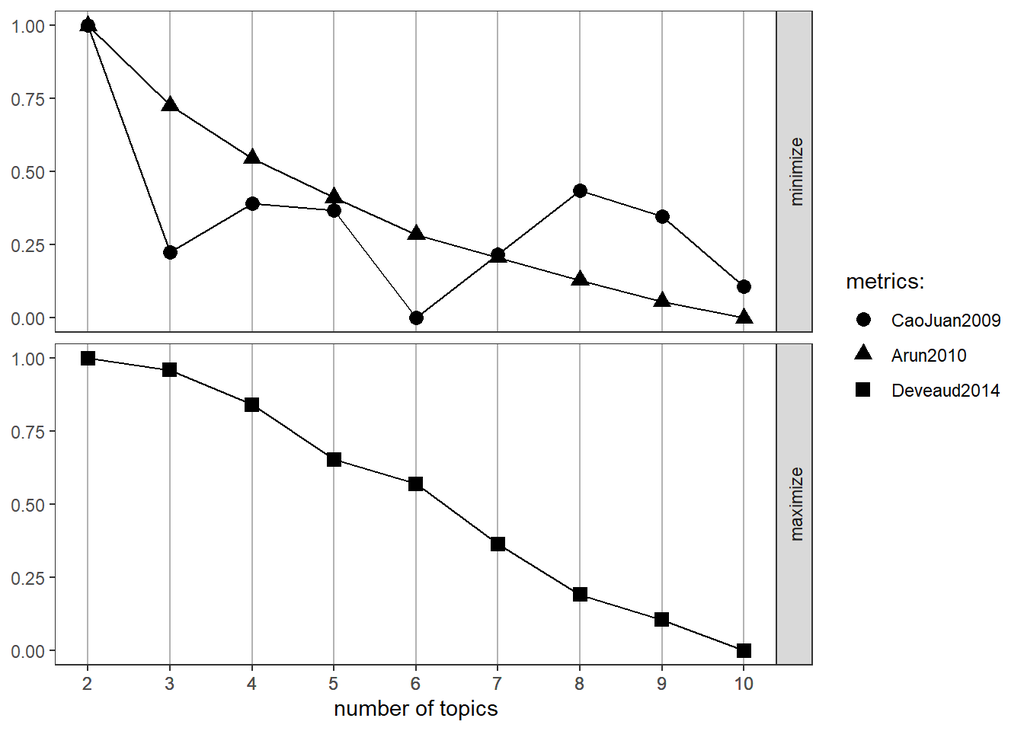

```r
# Visualizar los resultados
FindTopicsNumber_plot(coherencia)
```

##### Evaluación de Perplexidad

Como complemento al análisis de coherencia, se considerará la perplexity (perplejidad) como un segundo criterio para la determinación del valor óptimo de K. En este enfoque, el objetivo es identificar el valor de K que minimice la perplejidad, lo que generalmente conduce a una mejor interpretabilidad del modelo. Un valor más bajo de perplejidad indica que el modelo es más capaz de predecir nuevas observaciones, lo que sugiere una mayor capacidad para capturar la estructura subyacente de los datos.

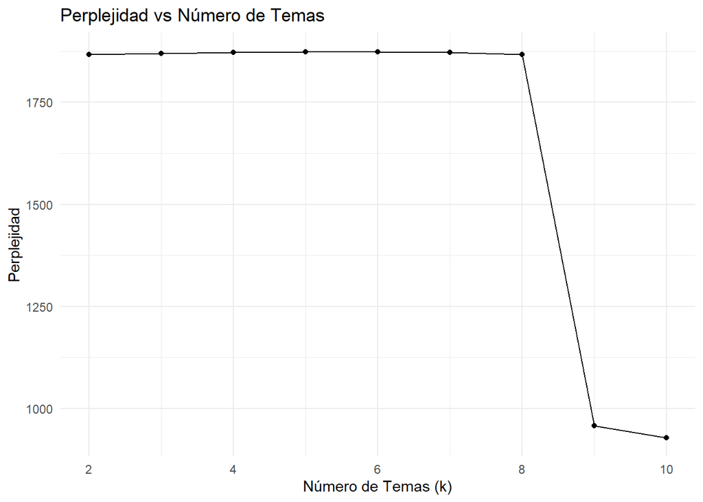

```r
# Creamos una función que calcule el modelo con diferentes K

perplexity_k <- function(temas) {
  lda_model <- LDA(dfm_toks, k = temas, control = list(seed = 1234))
  perplexity(lda_model)
}


k_valores <- seq(2,10,by = 1)

# Calculamos
perplejidades <- sapply(k_valores, perplexity_k)


# Visualizar la perplejidad
perplejidades <- data.frame(
  k = k_valores,
  perplejidad = perplejidades
)

ggplot(perplejidades, aes(x = k, y = perplejidad)) +
  geom_line() +
  geom_point() +
  labs(x = "Número de Temas (k)", y = "Perplejidad",
       title = "Perplejidad vs Número de Temas") +
  theme_minimal()
```

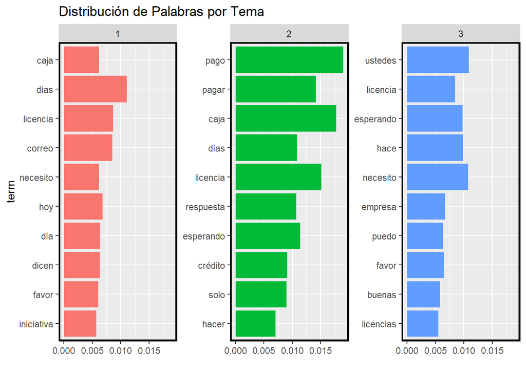

```r
# Generemos el modelo
lda_model <- LDA(dfm_matrix, k = 3, control = list(seed = 1234))


# Gráfica de distribución
topics <- tidytext::tidy(lda_model, matrix = "beta")

topterms <-
  topics %>%
  group_by(topic) %>%
  top_n(10, beta) %>%
  ungroup() %>%
  arrange(topic, -beta)


topterms  %>%
  mutate(term = reorder(term, beta)) %>%
  ggplot(aes(term,beta, fill = factor(topic))) +
  geom_col(show.legend = FALSE) +
  ylab("") +
  facet_wrap(~topic, scales = "free_y", nrow = 5, ncol = 3)+
  coord_flip() +
  theme(panel.border = element_rect(fill = "transparent",
                                    color = "black", linewidth = 1.5)) +
        labs(title =  "Distribución de Palabras por Tema")
```

```r
phi <- posterior(lda_model)$terms
theta <- posterior(lda_model)$topics
vocab <- colnames(phi)
doc_length <- rowSums(as.matrix(dfm_matrix))
term_frequency <- colSums(as.matrix(dfm_matrix))

# Crear la lista con la información para LDAvis
json_lda <- createJSON(phi = phi,
                       theta = theta,
                       doc.length = doc_length,
                       vocab = vocab,
                       term.frequency = term_frequency)


serVis(json_lda, out.dir = 'LDAvis', open.browser = FALSE)
```

#### ANÁLISIS DE SENTIMIENTO

En primera instancia, utilizaremos el método NRC para el análisis de sentimientos. Este método se basa en un léxico que asocia palabras con una de las ocho emociones básicas. Una ventaja significativa del método NRC es que es el único léxico disponible actualmente en español, además de estar disponible en varios otros idiomas, lo que lo hace especialmente adecuado para nuestro análisis multilingüe.

```r
datos1 <- datos

datos1 <- as.data.frame(gsub("http\\S+", "", datos1$texto_tweet))
names(datos1) <- "tweets"

datos1 <- as.data.frame(gsub("@\\w+", "", datos1$tweets))
names(datos1) <- "tweets"

datos1 <- as.data.frame(gsub("#\\w+", "", datos1$tweets))
names(datos1) <- "tweets"

datos1$tweets <- tolower(datos1$tweets)

datos1 <- as.data.frame(gsub("[[:punct:]]", "", datos1$tweets))
names(datos1) <- "tweets"

datos1 <- as.data.frame(gsub("[[:digit:]]", "", datos1$tweets))
names(datos1) <- "tweets"

datos1 <- as.data.frame(stringi::stri_replace_all_regex(datos1$tweets,"[\\p{So}\\p{Sk}]+", "", opts_regex = stringi::stri_opts_regex(case_insensitive = TRUE)))
names(datos1) <- "tweets"

# Stopwords
stopwords_es <- c("de", "la", "que", "el", "en", "y", "a", "los", "se", "del", "las", "un", "por", "con", "no", "una", "su", "para", "es", "al", "lo", "como", "más", "pero", "sus", "le", "ya", "o", "este", "sí", "porque", "esta", "entre", "cuando", "muy", "sin", "sobre", "también", "me", "hasta", "hay", "donde", "quien", "desde", "todo", "nos", "durante", "todos", "uno", "les", "ni", "contra", "otros", "ese", "eso", "ante", "ellos", "e", "esto", "mí", "antes", "algunos", "qué", "unos", "yo", "otro", "otras", "otra", "él", "tanto", "esa", "estos", "mucho", "quienes", "nada", "muchos", "cual", "poco", "ella", "estar", "estas", "algunas", "algo", "nosotros")
datos1$tweets <- removeWords(datos1$tweets, stopwords_es)

# Clasificar palabras
sentiments <- get_nrc_sentiment(datos1$tweets, language = "spanish")

print(head(sentiments))
```

```
##   anger anticipation disgust fear joy sadness surprise trust negative positive
## 1     0            0       0    0   1       0        0     1        1        3
## 2     1            2       0    0   2       0        0     2        0        2
## 3     0            0       0    0   0       0        0     1        0        1
## 4     0            0       0    0   0       0        0     1        1        1
## 5     0            0       0    0   0       0        0     2        1        1
## 6     0            0       0    0   1       0        0     0        0        1
```

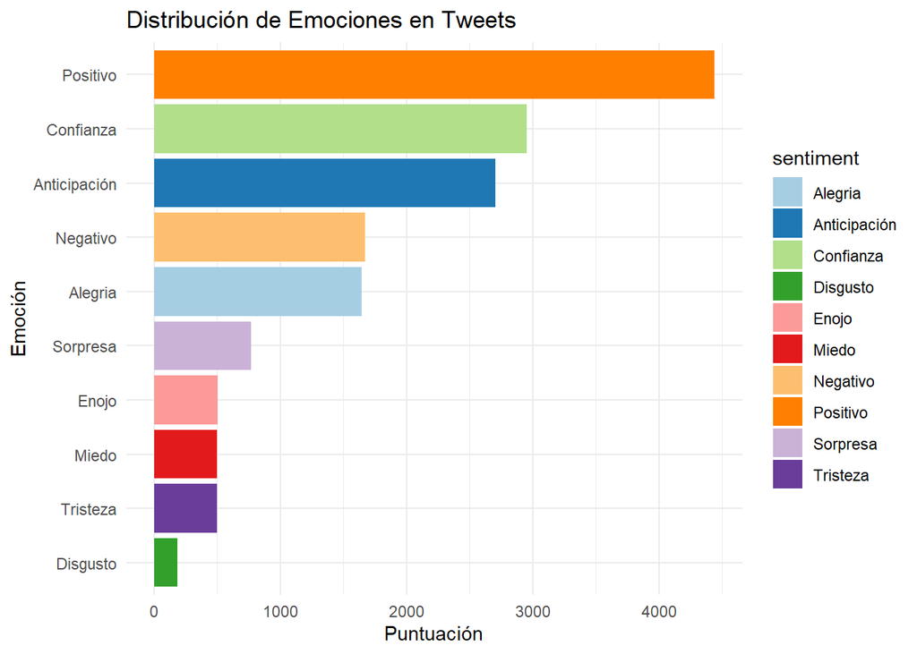

```r
# Visualización
resumen_sentimientos <- colSums(sentiments[,1:10])

df_sentiments <- data.frame(sentiment = names(resumen_sentimientos),
                            score = resumen_sentimientos)

df_sentiments$sentiment <- c("Enojo","Anticipación","Disgusto","Miedo","Alegria","Tristeza", "Sorpresa", "Confianza","Negativo","Positivo")

# Gráfico de barras de emociones
ggplot(df_sentiments, aes(x = reorder(sentiment,score), y = score, fill = sentiment)) +
  geom_bar(stat = "identity") +
  theme_minimal() +
  labs(title = "Distribución de Emociones en Tweets", x = "Emoción", y = "Puntuación") +
  coord_flip() +  # Hace que el gráfico sea horizontal
  scale_fill_brewer(palette = "Paired")  # Usa una paleta de colores agradable
```

Veamos la relación de positivos y negativos

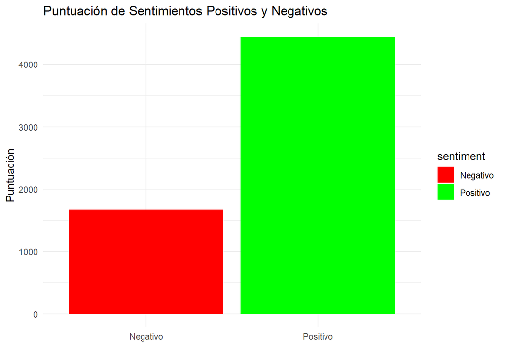

```r
positive_negative <- colSums(sentiments[,c("positive", "negative")])

# Gráfico para positivos y negativos
df_pos_neg <- data.frame(sentiment = names(positive_negative), score = positive_negative)
df_pos_neg$sentiment <- c("Positivo","Negativo")

ggplot(df_pos_neg, aes(x = sentiment, y = score, fill = sentiment)) +
  geom_bar(stat = "identity") +
  theme_minimal() +
  labs(title = "Puntuación de Sentimientos Positivos y Negativos", x = "", y = "Puntuación") +
  scale_fill_manual(values = c("red", "green"))
```

En un análisis preliminar, observamos que las emociones predominantes entre los comentarios son de carácter positivo. Para profundizar en esta observación, procederemos a examinar en detalle algunos textos donde las palabras positivas sean más prevalentes, con el objetivo de obtener una comprensión más precisa de los sentimientos expresados.

#### Textos con más palabras más positivas y textos con más palabras negativas

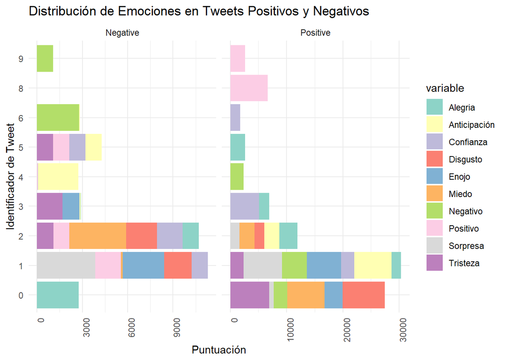

```r
# Veamos como se comportaron los tweets con más palabras positivas, y los con más
# palabras negativas


# Ordenar y obtener las posiciones de los 10 textos más positivos
top_5_positive_indices <- order(sentiments$positive, decreasing = TRUE)[1:5]

# Ordenar y obtener las posiciones de los 10 textos más negativos
top_5_negative_indices <- order(sentiments$negative, decreasing = TRUE)[1:5]



sub_pos <- as.data.frame(datos1[top_5_positive_indices,])
sub_pos$sentimiento <- "Positive"
sub_pos$Texto <- top_5_positive_indices

names(sub_pos) <- c("Tweets", "Sentimiento","Texto")

sub_neg <- as.data.frame(datos1[top_5_negative_indices,])
sub_neg$sentimiento <- "Negative"
sub_neg$Texto <- top_5_negative_indices

names(sub_neg) <- c("Tweets", "Sentimiento","Texto")

sub_pos_neg <- rbind(sub_pos, sub_neg)

sub_pos_neg$Sentimiento <- as.factor(sub_pos_neg$Sentimiento)

sub_pos_neg_sentiments <- get_nrc_sentiment(sub_pos_neg$Tweets, language = "spanish")

sub_pos_neg_sentiments$Sentimiento <- sub_pos_neg$Sentimiento
sub_pos_neg_sentiments$TweetID <- sub_pos_neg$Texto

data_long <- reshape2::melt(sub_pos_neg_sentiments, id.vars = c("TweetID", "Sentimiento"), measure.vars = names(sub_pos_neg_sentiments))

sentimientos_es <- c("Enojo","Anticipación","Disgusto","Miedo","Alegria","Tristeza", "Sorpresa", "Confianza","Negativo","Positivo","Sentimiento","TweetID")

sentimientos_es <-  rep(sentimientos_es, each = 10)

data_long$variable <- sentimientos_es

data_long[1:100,] %>%
ggplot( aes(x = TweetID, y = value, fill = variable)) +
  geom_bar(stat = "identity", position = "stack") +
  facet_wrap(~ Sentimiento, scales = "free_x") +
  labs(title = "Distribución de Emociones en Tweets Positivos y Negativos", x = "Puntuación", y = "Identificador de Tweet") +
  scale_fill_brewer(palette = "Set3") +
  theme_minimal() +
  theme(axis.text.x = element_text(angle = 90, hjust = 1))
```

```r
# Combinar los textos en una tabla
result_table <- data.frame(
  "Textos con Más Palabras Positivas" = sub_pos$Tweets,
  "Textos con Más Palabras Negativas" = sub_neg$Tweets
)


pander::pander(result_table, format = "markdown", align = "l")
```

| Textos.con.Más.Palabras.Positivas | Textos.con.Más.Palabras.Negativas |
| --- | --- |
| programa tremendo ver adultos mayores disfrutando buen momento excelente modelo era adulto mayor maravilloso | han podido pagar mi licencia sólo error humano momento digitar número mi cta hacen mal llamé dicen tengo esperar vez rechazo pago banco poder gestionar nuevo |
| encontramos aliado cumplir propósito educar empoderarte financieramente juntos buscamos mejorar salud financiera personas revisa aquí detalles | ojalá descuente cuota crédito terminó pagar devolver te han descontado mal esperar ene |
| súper acuerdo ministra pasado mitad mi vida laboral trabajando estado distintos órganos recuerdo q estado empleadores abusadores urge abordar figura honorarios estado regular horarios laborales | aún espero pago mi licencia enero mal cálculo caja debo esperar marzo justo |
| hola comento hicieron pebre descuento mes denunciaré suceso puesto pagué seguro cesantia siempre momento quedar cesante ser mutuo acuerdo respetaron seguro | estimados envié solicitud hace días gestión mes embarazo recién hoy escribí saber pasaba responden estaba mal reenvié altiro ver si ahora está bien responden ósea tendré esperar nuevamente |
| saludo iniciativa disminuir jornada laboral trabajadoresas anunciada hace días puede mejorar calidad vida personas puede diálogo necesario trabajaremos decididamente jornada | problema parecer personal oficinas está capacitado mal trato público empatía llevo dos meses esperando llamarán dijeran cuál era problema encima siguen haciendo esperar |

### Combinando LDA y sentimientos

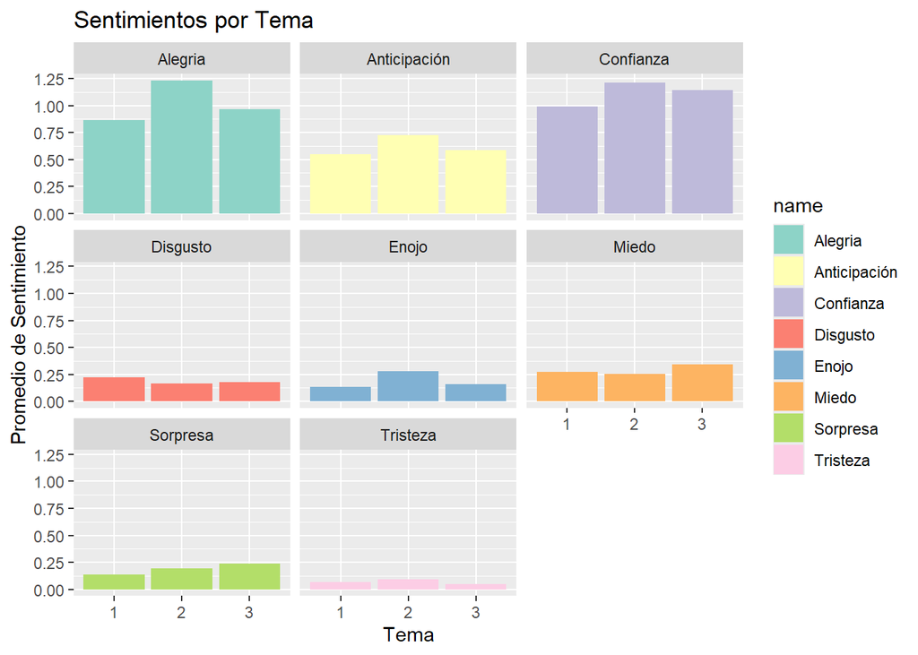

```r
sentiments_scores <- sentiments

# Agregar puntajes de sentimientos al dataframe original
datos1 <- datos1 %>%
  mutate(paste("text", row_number(), sep = ""))

names(datos1)[2] <- "document"
data_with_sentiments <- data.frame(datos1, sentiments_scores)

# Asignar documentos a temas
document_topics <- tidy(lda_model, matrix = "gamma") %>%
  group_by(document) %>%
  top_n(1, gamma) %>%
  ungroup()


# Combinar temas con sentimientos
combined_analysis <- document_topics %>%
  left_join(data_with_sentiments, by = "document")

# Analizar sentimientos por tema
sentiments_by_topic <- combined_analysis %>%
  group_by(topic) %>%
  summarise(across(starts_with("anger"), mean, na.rm = TRUE),
            across(starts_with("joy"), mean, na.rm = TRUE),
            across(starts_with("sadness"), mean, na.rm = TRUE),
            across(starts_with("surprise"), mean, na.rm = TRUE),
            across(starts_with("anticipation"), mean, na.rm = TRUE),
            across(starts_with("disgust"), mean, na.rm = TRUE),
            across(starts_with("fear"), mean, na.rm = TRUE),
            across(starts_with("trust"), mean, na.rm = TRUE),
            .groups = 'drop')

resumen <- sentiments_by_topic %>%
  pivot_longer(cols = c(-topic))

sentimientos_es <- c("Enojo","Anticipación","Disgusto","Miedo","Alegria","Tristeza", "Sorpresa", "Confianza")

sentimientos_es <- rep(sentimientos_es,3)


resumen$name <- sentimientos_es

# Gráfico de sentimientos por tema
ggplot(resumen, aes(x = factor(topic), y = value, fill = name)) +
  geom_bar(stat = "identity") +
  facet_wrap(~name) +
  labs(title = "Sentimientos por Tema", x = "Tema", y = "Promedio de Sentimiento") +
  scale_fill_brewer(palette = "Set3")
```

### Conclusión

El análisis de los tweets relacionados con Caja los Andes ha permitido identificar tanto las principales emociones expresadas por los usuarios como los temas predominantes que surgen en sus interacciones. A través de un proceso detallado que incluyó el pre-procesamiento de datos, la visualización inicial de las tendencias, la aplicación de Latent Dirichlet Allocation (LDA) para descubrir temáticas, y un análisis de sentimientos para evaluar las emociones presentes, hemos logrado obtener insights clave.

**Recomendaciones:** Este análisis ofrece una base sólida para que Caja los Andes tome medidas informadas en la gestión de su imagen y en la interacción con sus usuarios en redes sociales. Se recomienda: - Continuar monitoreando estos temas y emociones para detectar cambios en la percepción pública. - Considerar estrategias de comunicación que aborden las emociones negativas asociadas con temas específicos. - Implementar campañas de comunicación dirigidas a fortalecer los aspectos positivos identificados. - Tener identificadores de fechas ayudaría a generar una análisis temporal de las opiniones de la gente.

En conclusión, el análisis proporciona una visión holística de cómo se percibe a Caja los Andes en las redes sociales, lo que puede guiar decisiones estratégicas en la comunicación y gestión de la relación con los clientes.